# NSL Notebook 09

```python
from default import *
```

## Exercise 09.1

**Traveling Salesman Problem | Genetic Algo**

Mutation and crossover choices:

- mutation probability $0.2$
- mutation types:
  - swap two cities
  - reverse a slice of cities
- crossover probability $0.8$

### Exercise 09.1.1

Solve **TSP** problem for 32 cities on circle.

Below the results, I plotted the trend of the best path at each optimization steps $L1$, and the trend of the average of the $10$ best paths $\langle L1 \rangle$.

So starting from $1000$ random population of paths after $40$ steps the best path has been found.

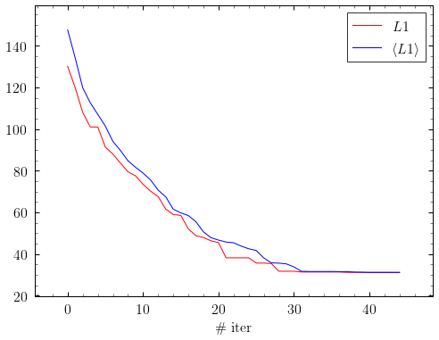

```python
fig, ax = plt.subplots(figsize=(8,6))

dfb = pd.read_csv('bL1OC.out', header=None, names=['L1'])
dfbh = pd.read_csv('bHAL1OC.out', header=None, names=['haL1'])

dfb['L1'].plot.line(ls='-', c='r', ax=ax, label="$L1$");
dfbh['haL1'].plot.line(ls='-', c='b', ax=ax, label="$\langle L1 \\rangle$");

ax.legend();
ax.set_xlabel('\# iter');
```

Below, instead, an HTML5 animation comparison between one of the initial random configurations, and the best path at the end of optimization.

```python
from matplotlib.animation import FuncAnimation
from time import sleep

fig, (axb, axa) = plt.subplots(1,2, figsize=(10,5));

dfb = pd.read_csv('circle.tsv',
                  header=None,
                  sep='\t',
                  names=['x','y']);
dfa = pd.read_csv('OC.csv',
                  header=None,
                  sep=',',
                  names=['x','y']);

xb = [dfb['x'][0]]
yb = [dfb['y'][0]]

xa = [dfa['x'][0]]
ya = [dfa['y'][0]]

def func(npt, *fargs):
    xb.append(npt[0][0])
    yb.append(npt[0][1])
    xa.append(npt[1][0])
    ya.append(npt[1][1])
    axb.plot(xb,yb, '-r');
    axa.plot(xa,ya, '-b');
    xb.pop(0)
    yb.pop(0)
    xa.pop(0)
    ya.pop(0)

def init_func():
    axb.scatter(dfb['x'], dfb['y'], marker='.', color='k');
    axa.scatter(dfa['x'], dfa['y'], marker='.', color='k');
    sleep(1);


frames = []
for ptb, pta in zip(np.asarray(dfb), np.asarray(dfa)):
    frames.append((ptb, pta))

anim = FuncAnimation(fig, func, frames, init_func, interval=300);
plt.close(fig=fig)

from IPython.display import HTML
HTML(anim.to_html5_video())
```

[video not shown]

### Exercise 09.1.2

Solve **TSP** problem for 32 cities inside a square.

Below the results, I plotted the trend of the best path at each optimization steps $L1$, and the trend of the average of the $10$ best paths $\langle L1 \rangle$.

So starting from $1000$ random population of paths after $40$ steps the best path has been found.

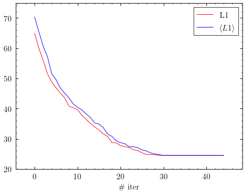

```python
fig, ax = plt.subplots(figsize=(8,6))

dfb = pd.read_csv('bL1IS.out', header=None, names=['L1'])
dfbh = pd.read_csv('bHAL1IS.out', header=None, names=['haL1'])

dfb['L1'].plot.line(ls='-', c='r', ax=ax, label="L1");
dfbh['haL1'].plot.line(ls='-', c='b', ax=ax, label="$\langle L1 \\rangle$");

ax.legend();
ax.set_xlabel('\# iter');
```

Below, instead, an HTML5 animation comparison between one of the initial random configurations, and the best path at the end of optimization.

```python
from matplotlib.animation import FuncAnimation
from time import sleep

fig, (axb, axa) = plt.subplots(1,2, figsize=(10,5));

dfb = pd.read_csv('square.tsv',
                  header=None,
                  sep='\t',
                  names=['x','y']);
dfa = pd.read_csv('IS.csv',
                  header=None,
                  sep=',',
                  names=['x','y']);

xb = [dfb['x'][0]]
yb = [dfb['y'][0]]

xa = [dfa['x'][0]]
ya = [dfa['y'][0]]

def func(npt, *fargs):
    xb.append(npt[0][0])
    yb.append(npt[0][1])
    xa.append(npt[1][0])
    ya.append(npt[1][1])
    axb.plot(xb,yb, '-r');
    axa.plot(xa,ya, '-b');
    xb.pop(0)
    yb.pop(0)
    xa.pop(0)
    ya.pop(0)

def init_func():
    axb.scatter(dfb['x'], dfb['y'], marker='.', color='k');
    axa.scatter(dfa['x'], dfa['y'], marker='.', color='k');
    sleep(1);


frames = []
for ptb, pta in zip(np.asarray(dfb), np.asarray(dfa)):
    frames.append((ptb, pta))

anim = FuncAnimation(fig, func, frames, init_func, interval=300, blit=False);
plt.close(fig=fig)

from IPython.display import HTML
HTML(anim.to_html5_video())
```

[video not shown]